# HW5_XianjieQue

XianjieQue

2025-02-25

## 8.2

Assuming the question is focused on boosting regression trees.

First, a decision tree with M terminal nodes ((M - 1) splits) is:

$$f(X) = \sum_{m=1}^{M} c_m \cdot 1(X \in R_m)$$

$c_m$ represents the mean of observations in region $R_m$.

A decision stump is a tree with only two terminal nodes ($M = 2$), meaning it performs a single split. If the stump splits on variable $X_j$ at threshold $s$, it can be written as:

$$f(X) = c_1 \cdot 1(X \in R_1) + c_2 \cdot 1(X \in R_2) =
\begin{cases}
c_1 & \text{if } X_j < s \\
c_2 & \text{if } X_j \geq s
\end{cases}
= c_1 \cdot I(X_j < s) + c_2 \cdot I(X_j \geq s)$$

Boosting doesn’t use just one stump but a sequence of $B$ stumps. I define:

- $b = 1,2, \dots, B$ as the iteration index.
- Each stump splits on a variable $X_{j_b}$, selected from $X_1, X_2, \dots, X_p$.
- Each stump has a threshold $s_b$.
- The predictions for each region are $\alpha_b$ and $\beta_b$.

Thus, at iteration $b$, the weak learner is:

$$\hat{f}_b(X) = \alpha_b \cdot I(X_{j_b} < s_b) + \beta_b \cdot
I(X_{j_b} \geq s_b)$$

Following Algorithm 8.2:

#### Step 1: Initialization

We start with $\hat{f}(X) = 0$ and initialize residuals as:

$$r_i = y_i, \quad \text{for all } i$$

#### Step 2: Iterative Boosting

For each iteration $b = 1, \dots, B$:

Iteration 1 ($b = 1$):

train a stump:

$$\hat{f}_1(X) = \alpha_1 \cdot I(X_{j_1} < s_1) + \beta_1 \cdot
I(X_{j_1} \geq s_1)$$

update the model:

$$\hat{f}(X) \leftarrow \hat{f}(X) + \lambda \hat{f}_1(X) = \lambda
\hat{f}_1(X)$$

update the residuals:

$$r_i \leftarrow r_i - \lambda \hat{f}_1(X) = y_i - \lambda \hat{f}_1(X)$$

Iteration 2 ($b = 2$):

train another stump:

$$\hat{f}_2(X) = \alpha_2 \cdot I(X_{j_2} < s_2) + \beta_2 \cdot
I(X_{j_2} \geq s_2)$$

update the model:

$$\hat{f}(X) \leftarrow \hat{f}(X) + \lambda \hat{f}_2(X) = \lambda
\hat{f}_1(X) + \lambda \hat{f}_2(X)$$

update the residuals:

$$r_i \leftarrow r_i - \lambda \hat{f}_2(X) = y_i - \lambda \hat{f}_1(X) -
\lambda \hat{f}_2(X)$$

until $B$ iterations:

At the final iteration ($b = B$):

$$\hat{f}_B(X) = \alpha_B \cdot I(X_{j_B} < s_B) + \beta_B \cdot
I(X_{j_B} \geq s_B)$$

update the model:

$$\hat{f}(X) \leftarrow \hat{f}(X) + \lambda \hat{f}_B(X) = \sum_{b=1}^{B}
\lambda \hat{f}_b(X)$$

final residuals:

$$r_i \leftarrow r_i - \lambda \hat{f}_B(X) = y_i - \sum_{b=1}^{B} \lambda
\hat{f}_b(X)$$

After $B$ boosting iterations, the final model is:

$$\hat{f}(X) = \sum_{b=1}^{B} \lambda \hat{f}_b(X) =
\lambda \sum_{b=1}^{B} \big[ \alpha_b \cdot I(X_{j_b} < s_b) +
\beta_b \cdot I(X_{j_b} \geq s_b) \big]$$

Since the splitting variables $X_{j_1}, X_{j_2}, \dots, X_{j_B}$ are chosen from $X_1, X_2, \dots, X_p$, this ultimately forms an additive model:

$$f(X) = \sum_{j=1}^{p} f_j(X_j)$$

## 8.5

the final classification under Majority Vote: Red the final classification under Average Probability: Green

```r
x <- c(0.1, 0.15, 0.2, 0.2, 0.55, 0.6, 0.6, 0.65, 0.7, 0.75)

ifelse(sum(x >= 0.5) > sum(x < 0.5), "red", "green") # majority vote
```

```
## [1] "red"
```

```r
ifelse(mean(x) > 0.5, "red", "green") # average probability
```

```
## [1] "green"
```

## 8.8

### 8.8 (a) Split the data set into a training set and a test set.

```r
# install.packages("ISLR2")
# install.packages("tree")
# install.packages("randomForest")
# install.packages("BART")
# install.packages("gbm")
# install.packages("ggplot2")
# install.packages("caret")

library(ISLR2)
library(tree)
library(randomForest)
library(dplyr)
library(BART)
library(gbm)
library(ggplot2)
library(caret)
set.seed(5)

train_index_8a <- sample(1:nrow(Carseats), nrow(Carseats) / 2)

train_8a <- Carseats[train_index_8a, ]
test_8a <- Carseats[-train_index_8a, ]
```

### 8.8 (b) Regression Tree Plot

interpret the results:

summary(reg_tree_8b) lists the variables that are used as internal nodes in the tree and the number of terminal nodes.

6 variables are used as internal nodes. “ShelveLoc” and “Price” are the two most important factors in predicting Sales, since they are on the top of the tree (means they provided the best split of the data).

The tree has a total of 20 terminal nodes.

The test MSE associated with the regression tree is 5.041825

```r
reg_tree_8b <- tree(Sales ~ ., train_8a)

summary(reg_tree_8b)
```

```
##
## Regression tree:
## tree(formula = Sales ~ ., data = train_8a)
## Variables actually used in tree construction:
## [1] "ShelveLoc"   "Price"       "Age"         "CompPrice"   "Income"
## [6] "Advertising"
## Number of terminal nodes:  20
## Residual mean deviance:  2.184 = 393.1 / 180
## Distribution of residuals:
##     Min.  1st Qu.   Median     Mean  3rd Qu.     Max.
## -3.79500 -1.06000  0.08106  0.00000  0.91510  4.47500
```

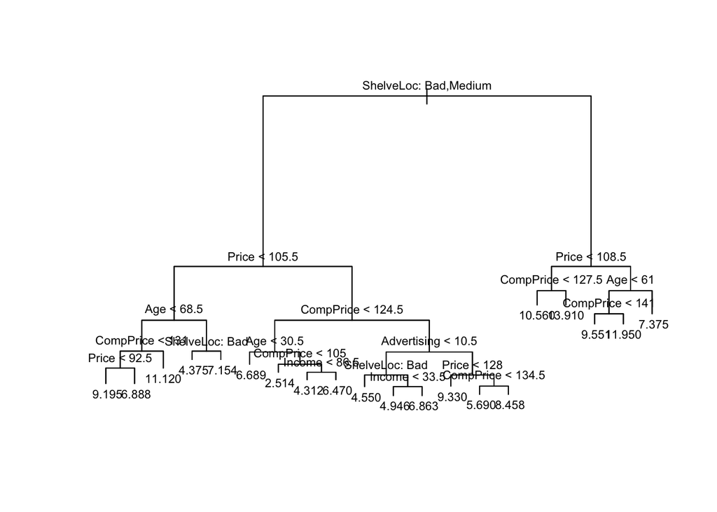

```r
plot(reg_tree_8b)
text(reg_tree_8b, pretty = 0, cex = 0.7)
```

```r
# test MSE
pred_sale <- predict(reg_tree_8b, test_8a)
mean((pred_sale - test_8a$Sales)^2)
```

```
## [1] 5.041825
```

### 8.8 (c) Cross-Validation

The optimal level of tree complexity is 20 terminal nodes.

I select the full tree with 20 terminal nodes (best = 20), and the test MSE is 5.041825. It is the same as in 8.8 (b).

Pruning the tree doesn’t improve the test MSE because the optimal tree is the fully grown tree without any pruning.

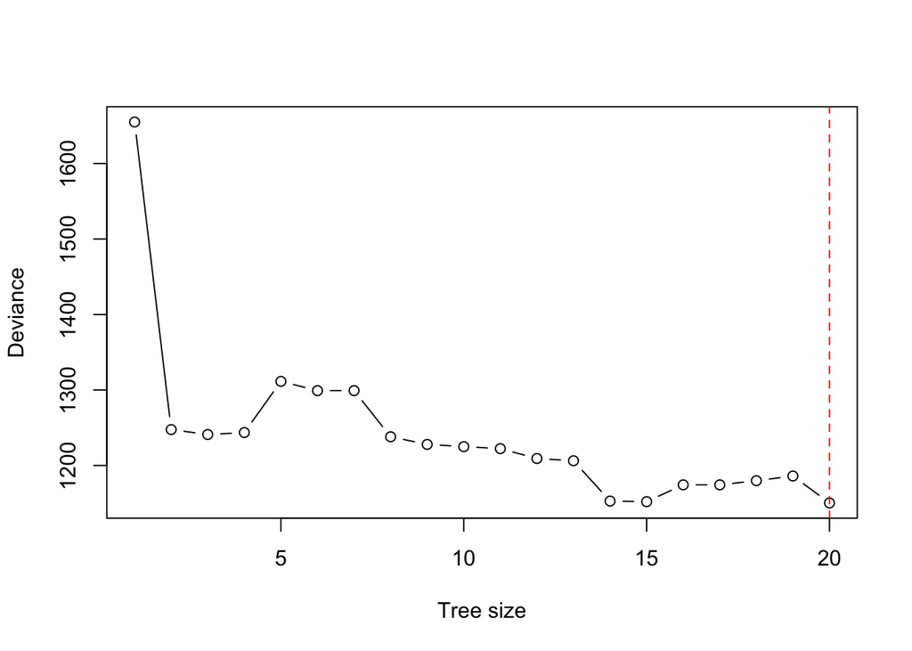

```r
set.seed(5)
cv_tree_8c <- cv.tree(reg_tree_8b)
plot(cv_tree_8c$size, cv_tree_8c$dev, type = "b",
     xlab = "Tree size", ylab = "Deviance")
min <- which.min(cv_tree_8c$dev)
abline(v = cv_tree_8c$size[min], lty = 2, col = "red")
```

```r
cv_tree_8c$size[min]
```

```
## [1] 20
```

```r
# prune the tree
prune_tree_8c <- prune.tree(reg_tree_8b, best = 20)
pred_prune_sale <- predict(prune_tree_8c, test_8a)
mean((pred_prune_sale - test_8a$Sales)^2)
```

```
## [1] 5.041825
```

### 8.8 (d) bagging approach

The test MSE is 2.616456, which is a substantial improvement over the pruned regression tree in 8.8 (c). It nearly reduces by 50%.

Based on “importance” result, “ShelveLoc” and “Price” are the two most important variables.

```r
set.seed(5)
bagged_8d <- randomForest(Sales ~ ., data = train_8a,
                               mtry = ncol(train_8a) - 1,
                               importance = T)
pred_bagged_sale <- predict(bagged_8d, test_8a)
mean((pred_bagged_sale - test_8a$Sales)^2)
```

```
## [1] 2.616456
```

```r
importance(bagged_8d)%>%
  as.data.frame() %>%
  arrange(desc(IncNodePurity))
```

```
##                %IncMSE IncNodePurity
## ShelveLoc   56.5023364    524.394271
## Price       41.5362308    354.351797
## CompPrice   24.5312572    198.116480
## Income       7.8958036    143.678550
## Age         15.2337344    141.216702
## Advertising 12.1177936    109.674044
## Population   0.1256964     53.477434
## Education    3.0652194     49.989640
## US           1.0587233      8.313148
## Urban        2.3943937      7.954334
```

### 8.8 (e) random forests

When mtry = 10, the error rate obtains min value, 2.616456, which is a substantial improvement over the pruned regression tree and equal to the bagging approach.

Based on “importance” result, “ShelveLoc” and “Price” are the two most important variables.

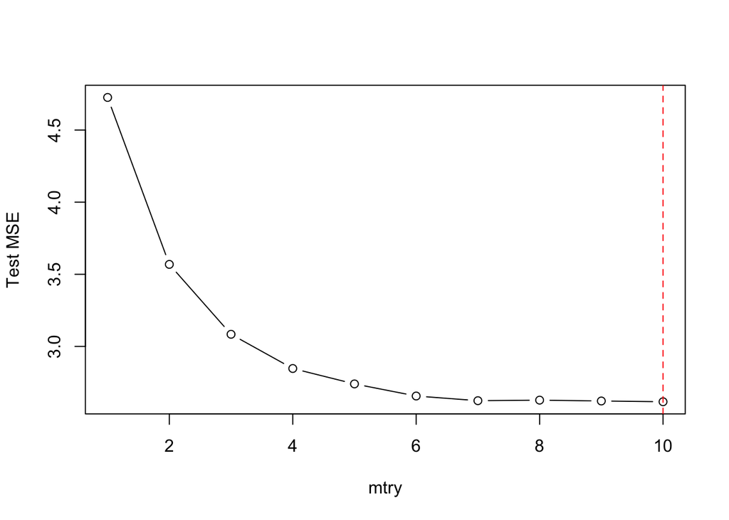

```r
test_MSE <- c()
i <- 1
for (Mtry in 1:10) {
  set.seed(5)
  rf_8e <- randomForest(Sales ~ ., data = train_8a,
                          mtry = Mtry,
                          importance = T)

  pred_8e <- predict(rf_8e, test_8a)

  test_MSE[i] <- mean((pred_8e - test_8a$Sales)^2)

  i <- i + 1
}

mtry <- 1:10
plot(mtry, test_MSE, type = "b",
     xlab = "mtry", ylab = "Test MSE")
min_8e <- which.min(test_MSE)
abline(v = mtry[min_8e], lty = 2, col = "red")
```

```r
mtry[min_8e]
```

```
## [1] 10
```

```r
min(test_MSE)
```

```
## [1] 2.616456
```

```r
importance(rf_8e)%>%
  as.data.frame() %>%
  arrange(desc(IncNodePurity))
```

```
##                %IncMSE IncNodePurity
## ShelveLoc   56.5023364    524.394271
## Price       41.5362308    354.351797
## CompPrice   24.5312572    198.116480
## Income       7.8958036    143.678550
## Age         15.2337344    141.216702
## Advertising 12.1177936    109.674044
## Population   0.1256964     53.477434
## Education    3.0652194     49.989640
## US           1.0587233      8.313148
## Urban        2.3943937      7.954334
```

### 8.8 (f) BART

We can also check how many times each variable appeared in the collection of trees.

```r
str(Carseats) # "Sales" is the first column in all of 11 columns
```

```
## 'data.frame':    400 obs. of  11 variables:
##  $ Sales      : num  9.5 11.22 10.06 7.4 4.15 ...
##  $ CompPrice  : num  138 111 113 117 141 124 115 136 132 132 ...
##  $ Income     : num  73 48 35 100 64 113 105 81 110 113 ...
##  $ Advertising: num  11 16 10 4 3 13 0 15 0 0 ...
##  $ Population : num  276 260 269 466 340 501 45 425 108 131 ...
##  $ Price      : num  120 83 80 97 128 72 108 120 124 124 ...
##  $ ShelveLoc  : Factor w/ 3 levels "Bad","Good","Medium": 1 2 3 3 1 1 3 2 3 3 ...
##  $ Age        : num  42 65 59 55 38 78 71 67 76 76 ...
##  $ Education  : num  17 10 12 14 13 16 15 10 10 17 ...
##  $ Urban      : Factor w/ 2 levels "No","Yes": 2 2 2 2 2 1 2 2 1 1 ...
##  $ US         : Factor w/ 2 levels "No","Yes": 2 2 2 2 1 2 1 2 1 2 ...
```

```r
bart_8f <- gbart(train_8a[, 2:11], train_8a[, 1],
  x.test = test_8a[, 2:11]
)
```

```
## *****Calling gbart: type=1
## *****Data:
## data:n,p,np: 200, 14, 200
## y1,yn: 0.138150, 0.058150
## x1,x[n*p]: 123.000000, 0.000000
## xp1,xp[np*p]: 124.000000, 1.000000
## *****Number of Trees: 200
## *****Number of Cut Points: 64 ... 1
## *****burn,nd,thin: 100,1000,1
## *****Prior:beta,alpha,tau,nu,lambda,offset: 2,0.95,0.284787,3,0.238753,7.38185
## *****sigma: 1.107106
## *****w (weights): 1.000000 ... 1.000000
## *****Dirichlet:sparse,theta,omega,a,b,rho,augment: 0,0,1,0.5,1,14,0
## *****printevery: 100
##
## MCMC
## done 0 (out of 1100)
## done 100 (out of 1100)
## done 200 (out of 1100)
## done 300 (out of 1100)
## done 400 (out of 1100)
## done 500 (out of 1100)
## done 600 (out of 1100)
## done 700 (out of 1100)
## done 800 (out of 1100)
## done 900 (out of 1100)
## done 1000 (out of 1100)
## time: 6s
## trcnt,tecnt: 1000,1000
```

```r
yhat.bart <- bart_8f$yhat.test.mean
mean((yhat.bart - test_8a$Sales)^2)
```

```
## [1] 1.555908
```

```r
ord <- order(bart_8f$varcount.mean, decreasing = T)
bart_8f$varcount.mean[ord]
```

```
##       Price  ShelveLoc2   CompPrice  ShelveLoc1      Urban2         US1
##      23.288      18.207      18.026      17.310      16.943      16.931
##  ShelveLoc3         Age   Education         US2  Population      Urban1
##      16.898      16.640      16.612      16.547      15.733      15.153
##      Income Advertising
##      15.040      14.287
```

## 8.9

### 8.9 (a)

```r
str(OJ)
```

```
## 'data.frame':    1070 obs. of  18 variables:
##  $ Purchase      : Factor w/ 2 levels "CH","MM": 1 1 1 2 1 1 1 1 1 1 ...
##  $ WeekofPurchase: num  237 239 245 227 228 230 232 234 235 238 ...
##  $ StoreID       : num  1 1 1 1 7 7 7 7 7 7 ...
##  $ PriceCH       : num  1.75 1.75 1.86 1.69 1.69 1.69 1.69 1.75 1.75 1.75 ...
##  $ PriceMM       : num  1.99 1.99 2.09 1.69 1.69 1.99 1.99 1.99 1.99 1.99 ...
##  $ DiscCH        : num  0 0 0.17 0 0 0 0 0 0 0 ...
##  $ DiscMM        : num  0 0.3 0 0 0 0 0.4 0.4 0.4 0.4 ...
##  $ SpecialCH     : num  0 0 0 0 0 0 1 1 0 0 ...
##  $ SpecialMM     : num  0 1 0 0 0 1 1 0 0 0 ...
##  $ LoyalCH       : num  0.5 0.6 0.68 0.4 0.957 ...
##  $ SalePriceMM   : num  1.99 1.69 2.09 1.69 1.69 1.99 1.59 1.59 1.59 1.59 ...
##  $ SalePriceCH   : num  1.75 1.75 1.69 1.69 1.69 1.69 1.69 1.75 1.75 1.75 ...
##  $ PriceDiff     : num  0.24 -0.06 0.4 0 0 0.3 -0.1 -0.16 -0.16 -0.16 ...
##  $ Store7        : Factor w/ 2 levels "No","Yes": 1 1 1 1 2 2 2 2 2 2 ...
##  $ PctDiscMM     : num  0 0.151 0 0 0 ...
##  $ PctDiscCH     : num  0 0 0.0914 0 0 ...
##  $ ListPriceDiff : num  0.24 0.24 0.23 0 0 0.3 0.3 0.24 0.24 0.24 ...
##  $ STORE         : num  1 1 1 1 0 0 0 0 0 0 ...
```

```r
set.seed(5)

train_index_9a <- sample(1:nrow(OJ), 800)

train_9a <- OJ[train_index_9a, ]
test_9a <- OJ[-train_index_9a, ]
```

### 8.9 (b) Classification Tree

The training error rate of 16.62% and the classification tree has 9 terminal nodes.

Although there are 17 predictors in the dataset (18 - “Purchase”), only 3 are used in splits. They are “LoyalCH”, “PriceDiff” and “ListPriceDiff”.

```r
OJ_tree_9b = tree(Purchase ~ ., train_9a)
summary(OJ_tree_9b)
```

```
##
## Classification tree:
## tree(formula = Purchase ~ ., data = train_9a)
## Variables actually used in tree construction:
## [1] "LoyalCH"       "PriceDiff"     "ListPriceDiff"
## Number of terminal nodes:  9
## Residual mean deviance:  0.7347 = 581.1 / 791
## Misclassification error rate: 0.1662 = 133 / 800
```

### 8.9 (c) a detailed text output

I choose Node 15), which is a terminal node marked by *:

15. LoyalCH > 0.705326 288 99.77 CH ( 0.95833 0.04167 ) *

Starting from the root node:

1. root 800 1068.00 CH ( 0.61250 0.38750 )

From the root node, three splits take place to produce Node 15):

A split at LoyalCH = 0.5036 A split at PriceDiff = -0.39 A split at LoyalCH = 0.705326

Node 15) is therefore the subset of purchases where LoyalCH > 0.705326 and PriceDiff > -0.39. The overall prediction is CH, and the node seems quite pure with 95.833% CH vs 4.167% MM.

There are 288 observations in Node 15), and from the percentages above we know that 276/288 are CH and 12/288 are MM.

Also, we can calculate the deviance of Node 15) by the formula. The result is same as 99.77

```r
OJ_tree_9b
```

```
## node), split, n, deviance, yval, (yprob)
##       * denotes terminal node
##
##  1) root 800 1068.00 CH ( 0.61250 0.38750 )
##    2) LoyalCH < 0.5036 346  412.40 MM ( 0.28324 0.71676 )
##      4) LoyalCH < 0.280875 164  125.50 MM ( 0.12805 0.87195 )
##        8) LoyalCH < 0.0356415 56   10.03 MM ( 0.01786 0.98214 ) *
##        9) LoyalCH > 0.0356415 108  103.50 MM ( 0.18519 0.81481 ) *
##      5) LoyalCH > 0.280875 182  248.00 MM ( 0.42308 0.57692 )
##       10) PriceDiff < 0.05 71   67.60 MM ( 0.18310 0.81690 ) *
##       11) PriceDiff > 0.05 111  151.30 CH ( 0.57658 0.42342 ) *
##    3) LoyalCH > 0.5036 454  362.00 CH ( 0.86344 0.13656 )
##      6) PriceDiff < -0.39 31   40.32 MM ( 0.35484 0.64516 )
##       12) LoyalCH < 0.638841 10    0.00 MM ( 0.00000 1.00000 ) *
##       13) LoyalCH > 0.638841 21   29.06 CH ( 0.52381 0.47619 ) *
##      7) PriceDiff > -0.39 423  273.70 CH ( 0.90071 0.09929 )
##       14) LoyalCH < 0.705326 135  143.00 CH ( 0.77778 0.22222 )
##         28) ListPriceDiff < 0.255 67   89.49 CH ( 0.61194 0.38806 ) *
##         29) ListPriceDiff > 0.255 68   30.43 CH ( 0.94118 0.05882 ) *
##       15) LoyalCH > 0.705326 288   99.77 CH ( 0.95833 0.04167 ) *
```

```r
# calculate the percentage in Node 15)
train_9a %>%
  filter(LoyalCH > 0.705326,
         PriceDiff > -0.39) %>%
  select(Purchase) %>%
  table()
```

```
## Purchase
##  CH  MM
## 276  12
```

```r
# calculate the deviance in Node 15)
-2 * (276 * log(276/288) + 12 * log(12/288))
```

```
## [1] 99.7662
```

### 8.9 (d) plot

“LoyalCH” is the most important variable (the root node splits on this variable), followed by “PriceDiff” and “ListPriceDiff”. Node 15) is the last terminal node.(from left)

LoyalCH ranges from 0 to 1, so the first split sends those less LoyalCH orange juice to the left and those more loyal to the right.

Those that scored lowest in LoyalCH (LoyalCH < 0.280875) were predicted to buy MM. Those that were slightly more loyal to CH (0.280875 < LoyalCH < 0.5036) would still buy MM if it wasn’t too much more expensive (PriceDiff < 0.05), but if the price difference is large than 0.05 (CH was much cheaper) they could end up purchasing CH.

Those on the far-right terminal node are the more loyal to CH (LoyalCH > 0.5036), so it should be unsurprising that CH is their predicted purchase. However, there is a exceptation. Those with slightly lower brand loyalty (0.5036 < LoyalCH < 0.638841), would purchase MM if it was cheaper (PriceDiff < -0.39).

In summary, people go with the brand they are more loyal towards, but there are some edge cases (based on the prices relative to one another) that can sway people against their usual brand loyalties.

Besides, There are 3 split points worthy to note: LoyalCH < 0.0356415 LoyalCH < 0.705326 ListPriceDiff < 0.255 The predicted categories of the terminal nodes after these 3 splits remain the same. These appear to be unnecessary splits. It is possible that the splits resulted in sufficient impurity reduction, leading the algorithm to proceed with them.

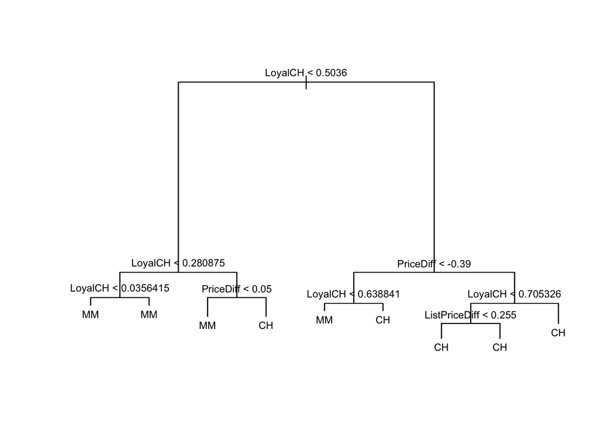

```r
plot(OJ_tree_9b)
text(OJ_tree_9b, pretty = 0, cex = 0.7)
```

### 8.9 (e) predict and test error rate

The test error rate is 17.41%

```r
# produce a confusion matrix
pred_9e <- predict(OJ_tree_9b, test_9a, type = "class")
table(pred_9e, actual_test = test_9a$Purchase)
```

```
##        actual_test
## pred_9e  CH  MM
##      CH 148  32
##      MM  15  75
```

```r
# calculate the test error rate
(32 + 15)/(148 + 75 + 32 + 15)
```

```
## [1] 0.1740741
```

```r
1 - mean(pred_9e == test_9a$Purchase)
```

```
## [1] 0.1740741
```

### 8.9 (f) determine the optimal tree size

The tree with 9 terminal nodes results in only 148 cross-validation errors, which is the lowest cross-validated classification error rate. So, the optimal tree size is with 9 terminal nodes.

```r
set.seed(5)
cv_OJ_9f <- cv.tree(OJ_tree_9b, FUN=prune.misclass)
cv_OJ_9f
```

```
## $size
## [1] 9 6 5 3 2 1
##
## $dev
## [1] 148 149 150 173 173 307
##
## $k
## [1]  -Inf   0.0   1.0   8.5   9.0 150.0
##
## $method
## [1] "misclass"
##
## attr(,"class")
## [1] "prune"         "tree.sequence"
```

### 8.9 (g) plot

The plot also shows the tree with 9 terminal nodes results in the lowest cross-validated classification error rate.

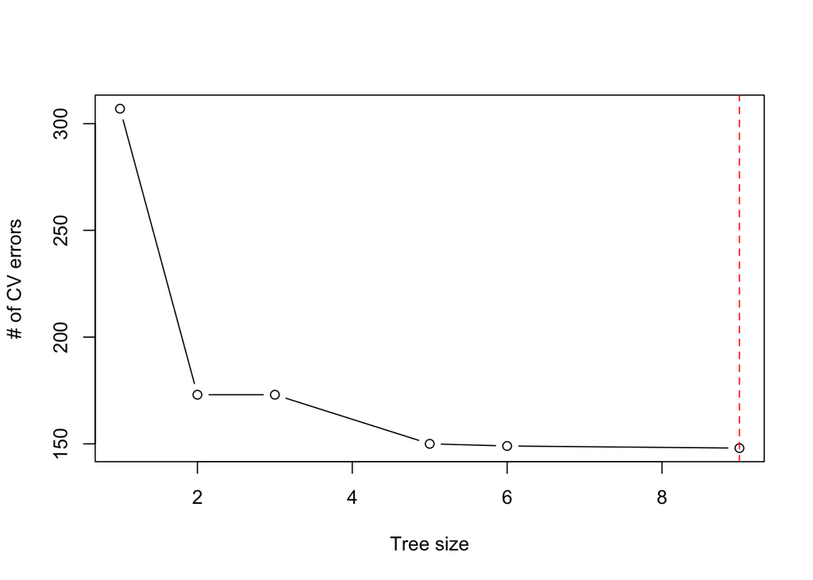

```r
plot(cv_OJ_9f$size, cv_OJ_9f$dev, type = "b",
     xlab = "Tree size", ylab = "# of CV errors")
min <- which.min(cv_OJ_9f$dev)
abline(v = cv_OJ_9f$size[min], lty = 2, col = "red")
```

```r
cv_OJ_9f$size[min]
```

```
## [1] 9
```

### 8.9 (h)

From the above results, the tree with 9 terminal nodes corresponds to the lowest cross-validated classification error rate, which is 148.

### 8.9 (i) Produce a pruned tree

Notice! After cross-validation, the optimal tree size is with 9 terminal nodes, same as the unpruned tree size. Cross-validation does not lead to selection of a pruned tree, so I create a pruned tree with 5 terminal nodes here.

```r
prune_OJ_9i <- prune.misclass(OJ_tree_9b, best = 5)
prune_OJ_9i
```

```
## node), split, n, deviance, yval, (yprob)
##       * denotes terminal node
##
##  1) root 800 1068.00 CH ( 0.61250 0.38750 )
##    2) LoyalCH < 0.5036 346  412.40 MM ( 0.28324 0.71676 )
##      4) LoyalCH < 0.280875 164  125.50 MM ( 0.12805 0.87195 ) *
##      5) LoyalCH > 0.280875 182  248.00 MM ( 0.42308 0.57692 )
##       10) PriceDiff < 0.05 71   67.60 MM ( 0.18310 0.81690 ) *
##       11) PriceDiff > 0.05 111  151.30 CH ( 0.57658 0.42342 ) *
##    3) LoyalCH > 0.5036 454  362.00 CH ( 0.86344 0.13656 )
##      6) PriceDiff < -0.39 31   40.32 MM ( 0.35484 0.64516 ) *
##      7) PriceDiff > -0.39 423  273.70 CH ( 0.90071 0.09929 ) *
```

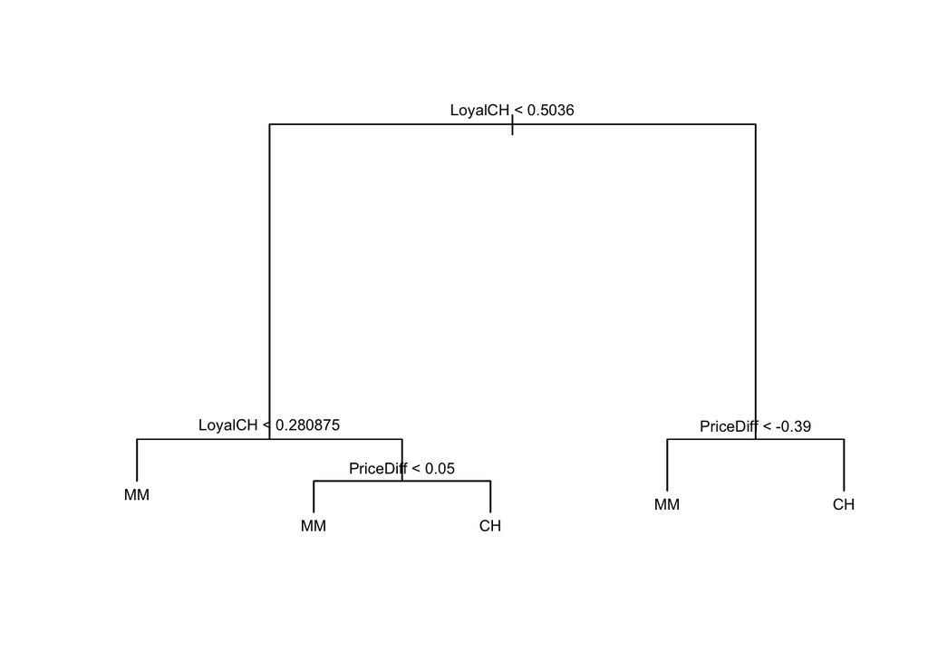

```r
plot(prune_OJ_9i)
text(prune_OJ_9i, pretty = 0, cex = 0.7)
```

### 8.9 (j) Compare the training error rates

0.16625 < 0.1675

The training error for the pruned tree is higher.

It’s not surprising because the training error of a tree to monotonically decrease as its flexibility (number of splits) increases.

```r
# the unpruned tree (9 terminal nodes)
mean(predict(OJ_tree_9b, type = "class") != train_9a$Purchase)
```

```
## [1] 0.16625
```

```r
# the pruned tree (5 terminal nodes)
mean(predict(prune_OJ_9i, type = "class") != train_9a$Purchase)
```

```
## [1] 0.1675
```

### 8.9 (k) Compare the test error rates

0.1740741 < 0.1777778

The test error for the pruned tree is higher.

This is contrary to my expectation. I thought the pruned tree would perform better on the test data set.

But this is because the pruned tree I used is not the optimal tree size selected through Cross-validation! The pruned tree I used here is the one I got in question 9 (i) which asked me to create a pruned tree with 5 terminal nodes. It is not the optimal tree size. In fact, the unpruned tree with 9 terminal nodes is already the optimal tree size. Therefore, the test error of “the pruned tree” will be higher than that of “unpruned tree”. Because the “unpruned tree” with 9 terminal nodes here is actually the optimal tree size.

```r
# the unpruned tree (9 terminal nodes)
mean(predict(OJ_tree_9b, type = "class", newdata = test_9a) != test_9a$Purchase)
```

```
## [1] 0.1740741
```

```r
# the pruned tree (5 terminal nodes)
mean(predict(prune_OJ_9i, type = "class", newdata = test_9a) != test_9a$Purchase)
```

```
## [1] 0.1777778
```

## 8.10

### 8.10 (a) missing data and log-transform

```r
str(Hitters)
```

```
## 'data.frame':    322 obs. of  20 variables:
##  $ AtBat    : int  293 315 479 496 321 594 185 298 323 401 ...
##  $ Hits     : int  66 81 130 141 87 169 37 73 81 92 ...
##  $ HmRun    : int  1 7 18 20 10 4 1 0 6 17 ...
##  $ Runs     : int  30 24 66 65 39 74 23 24 26 49 ...
##  $ RBI      : int  29 38 72 78 42 51 8 24 32 66 ...
##  $ Walks    : int  14 39 76 37 30 35 21 7 8 65 ...
##  $ Years    : int  1 14 3 11 2 11 2 3 2 13 ...
##  $ CAtBat   : int  293 3449 1624 5628 396 4408 214 509 341 5206 ...
##  $ CHits    : int  66 835 457 1575 101 1133 42 108 86 1332 ...
##  $ CHmRun   : int  1 69 63 225 12 19 1 0 6 253 ...
##  $ CRuns    : int  30 321 224 828 48 501 30 41 32 784 ...
##  $ CRBI     : int  29 414 266 838 46 336 9 37 34 890 ...
##  $ CWalks   : int  14 375 263 354 33 194 24 12 8 866 ...
##  $ League   : Factor w/ 2 levels "A","N": 1 2 1 2 2 1 2 1 2 1 ...
##  $ Division : Factor w/ 2 levels "E","W": 1 2 2 1 1 2 1 2 2 1 ...
##  $ PutOuts  : int  446 632 880 200 805 282 76 121 143 0 ...
##  $ Assists  : int  33 43 82 11 40 421 127 283 290 0 ...
##  $ Errors   : int  20 10 14 3 4 25 7 9 19 0 ...
##  $ Salary   : num  NA 475 480 500 91.5 750 70 100 75 1100 ...
##  $ NewLeague: Factor w/ 2 levels "A","N": 1 2 1 2 2 1 1 1 2 1 ...
```

```r
sum(is.na(Hitters$Salary)) # 59
```

```
## [1] 59
```

```r
Hitters_nNA <- Hitters[!is.na(Hitters$Salary), ]
Hitters_nNA$log_Salary <- log(Hitters_nNA$Salary)
```

### 8.10 (b) split training data set and test data set

```r
set.seed(5)

train_index_10b <- sample(1:nrow(Hitters_nNA), 200)

train_10b <- Hitters_nNA[train_index_10b, ]
test_10b <- Hitters_nNA[-train_index_10b, ]
```

### 8.10 (c) use a range of shrinkage values and plot

Since I log-transformed the salaries in 10(a), I use the new variable “log_Salary” for all questions.

I plot the results with X axis on a log10 scale.

The training MSE decreases as shrinkage values increase.

```r
set.seed(5)
lambda_seq <- 10^seq(-7, 0, 0.1)
train_MSE <- c()
test_MSE <- c()

for (i in 1:length(lambda_seq)) {
boost_10c <- gbm(log_Salary ~ . - Salary, data = train_10b,
                 distribution = "gaussian", n.trees = 1000,
                 interaction.depth = 4,   #  choosing interaction.depth = 4
                 shrinkage = lambda_seq[i])
 train_MSE[i] <- mean((predict(boost_10c, n.trees = 1000) - train_10b$log_Salary)^2)

  test_MSE[i] <- mean((predict(boost_10c, test_10b, n.trees = 1000) - test_10b$log_Salary)^2)
}
```

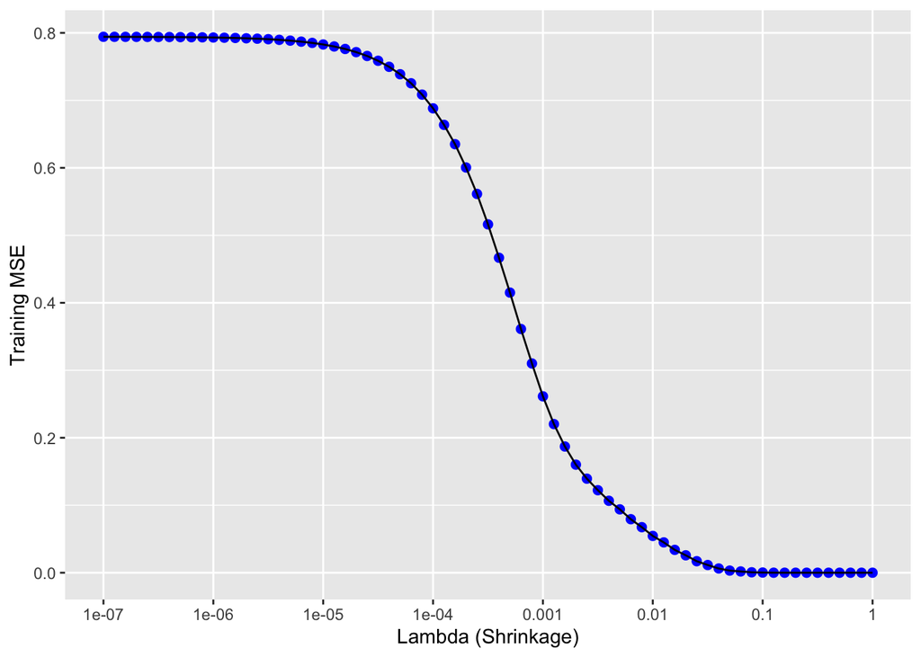

```r
data.frame(lambda = lambda_seq, train_MSE) %>%
  ggplot(aes(x = lambda, y = train_MSE)) +
  geom_point(size = 2, col = "blue") +
  geom_line(col = "black") +
  scale_x_continuous(trans = 'log10', breaks = 10^seq(-7, 0), labels = 10^seq(-7, 0), minor_breaks = NULL) +
  labs(x = "Lambda (Shrinkage)",
       y = "Training MSE")
```

### 8.10 (d) plot shrinkage values and test MSE

I’ve created the vector test_MSE in 10 (c) above.

As the shrinkage values increase, the corresponding change in test MSE differs from that of the training MSE; its variation is more complex.

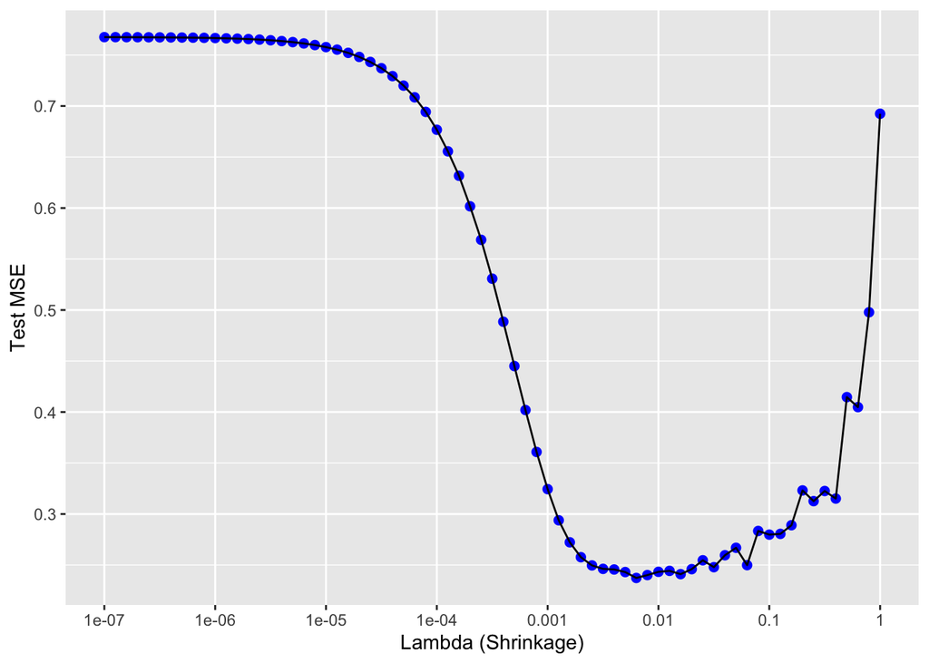

```r
data.frame(lambda = lambda_seq, test_MSE) %>%
  ggplot(aes(x = lambda, y = test_MSE)) +
  geom_point(size = 2, col = "blue") +
  geom_line(col = "black") +
  scale_x_continuous(trans = 'log10', breaks = 10^seq(-7, 0), labels = 10^seq(-7, 0), minor_breaks = NULL) +
  labs(x = "Lambda (Shrinkage)",
       y = "Test MSE")
```

### 8.10 (e) Boosting vs Linear Regression vs Lasso

I choose the following three methods for comparison:

Boosting ( The test MSE for the optimal shrinkage is 0.2444733 )

Linear Regression ( The test MSE for Linear Regression is 0.3766676 )

Lasso Regression ( The test MSE for Lasso Regression is 0.4137584 )

Conclusion: Boosting is the best-performing model in this case, followed by Linear Regression and then Lasso Regression. This suggests that Boosting captures complex relationships in the data better than the linear models. Linear Regression (0.3767) performs better than Lasso Regression (0.4138) but is still not as good as Boosting. Lasso Regression has the highest test MSE, suggesting that Lasso’s feature selection might have removed some important variables.

Below are the details.

First, I use Boosting to obtain the optimal value of shrinkage and the test MSE.

The optimal value of shrinkage is: 0.006309573

The test MSE for the optimal shrinkage is: 0.2444733

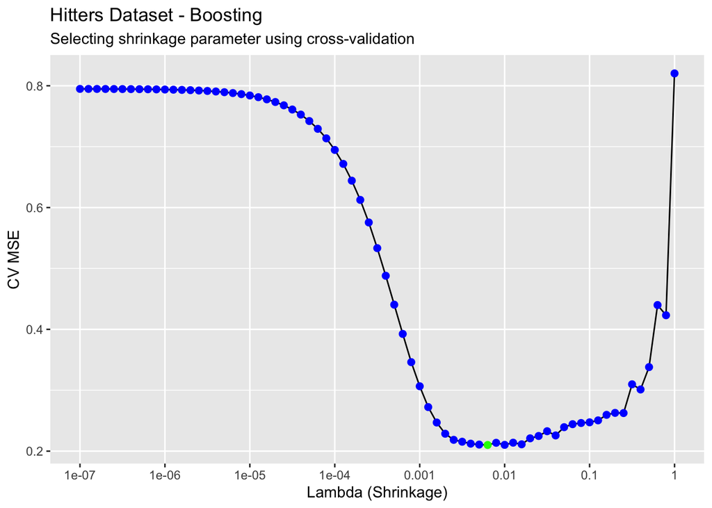

```r
set.seed(5)

k_folds <- 5
folds <- createFolds(train_10b$log_Salary, k = k_folds, list = TRUE, returnTrain = TRUE)

lambda_seq <- 10^seq(-7, 0, 0.1)
cv_results <- data.frame(lambda = lambda_seq, CV_MSE = rep(NA, length(lambda_seq)))

for (i in 1:length(lambda_seq)) {
  shrinkage_val <- lambda_seq[i]
  fold_MSE <- c()
  for (fold in folds) {
    train_fold <- train_10b[fold, ]
    test_fold <- train_10b[-fold, ]
    model_gbm <- gbm(log_Salary ~ . - Salary,
                     data = train_fold,
                     distribution = "gaussian",
                     n.trees = 1000,
                     interaction.depth = 4,
                     n.minobsinnode = 10,
                     shrinkage = shrinkage_val,
                     verbose = FALSE)

    predictions <- predict(model_gbm, test_fold, n.trees = 1000)
    MSE <- mean((predictions - test_fold$log_Salary)^2)
    fold_MSE <- c(fold_MSE, MSE)
  }

  cv_results$CV_MSE[i] <- mean(fold_MSE)
}

best_lambda <- cv_results$lambda[which.min(cv_results$CV_MSE)]

ggplot(cv_results, aes(x = lambda, y = CV_MSE)) +
  geom_line(col = "black") +
  geom_point(size = 2, aes(col = (lambda == best_lambda))) +
  scale_x_continuous(trans = 'log10', breaks = 10^seq(-7, 0), labels = 10^seq(-7, 0), minor_breaks = NULL) +
  scale_color_manual(values = c("blue", "green")) +
  theme(legend.position = "none") +
  labs(title = "Hitters Dataset - Boosting",
       subtitle = "Selecting shrinkage parameter using cross-validation",
       x = "Lambda (Shrinkage)",
       y = "CV MSE")
```

```r
# use best lambda (shrinkage) to obtain final model
best_model_gbm <- gbm(log_Salary ~ . - Salary,
                       data = train_10b,
                       distribution = "gaussian",
                       n.trees = 1000,
                       interaction.depth = 4,
                       n.minobsinnode = 10,
                       shrinkage = best_lambda,
                       verbose = FALSE)
test_pred_gbm <- predict(best_model_gbm, test_10b)
```

```
## Using 1000 trees...
```

```r
test_MSE_gbm <- mean((test_pred_gbm - test_10b$log_Salary)^2)

cat("The optimal value of shrinkage is:", best_lambda, "\n")
```

```
## The optimal value of shrinkage is: 0.006309573
```

```r
cat("The test MSE for the optimal shrinkage is:", test_MSE_gbm, "\n")
```

```
## The test MSE for the optimal shrinkage is: 0.2444733
```

Second, I use Linear Regression to obtain the test MSE.

The test MSE for Linear Regression is: 0.3766676

```r
linear_model <- lm(log_Salary ~ . - Salary, data = train_10b)

test_pred_lm <- predict(linear_model, test_10b)

test_MSE_lm <- mean((test_pred_lm - test_10b$log_Salary)^2)

cat("The test MSE for Linear Regression is:", test_MSE_lm, "\n")
```

```
## The test MSE for Linear Regression is: 0.3766676
```

Third, I use Lasso Regression to obtain the optimal value of shrinkage and the test MSE.

The optimal lambda for Lasso Regression is: 0.02084462

The test MSE for Lasso Regression is: 0.4137584

```r
library(glmnet)
x_train <- model.matrix(log_Salary ~ . - Salary, data = train_10b)[, -1]
y_train <- train_10b$log_Salary

x_test <- model.matrix(log_Salary ~ . - Salary, data = test_10b)[, -1]

set.seed(5)
lasso_cv <- cv.glmnet(x_train, y_train, alpha = 1)
best_lambda_lasso <- lasso_cv$lambda.min

lasso_model <- glmnet(x_train, y_train, alpha = 1, lambda = best_lambda_lasso)

test_pred_lasso <- predict(lasso_model, s = best_lambda_lasso, newx = x_test)

test_MSE_lasso <- mean((test_pred_lasso - test_10b$log_Salary)^2)

cat("The optimal lambda for Lasso Regression is:", best_lambda_lasso, "\n")
```

```
## The optimal lambda for Lasso Regression is: 0.02084462
```

```r
cat("The test MSE for Lasso Regression is:", test_MSE_lasso, "\n")
```

```
## The test MSE for Lasso Regression is: 0.4137584
```

```r
# check which variables are selected by lasso

lasso_coefficients <- coef(lasso_model, s = best_lambda_lasso)
lasso_coefficients
```

```
## 20 x 1 sparse Matrix of class "dgCMatrix"
##                        s1
## (Intercept)  4.5328316589
## AtBat        .
## Hits         0.0061711872
## HmRun        .
## Runs         .
## RBI          0.0003083155
## Walks        0.0044922907
## Years        0.0335199830
## CAtBat       .
## CHits        0.0003307718
## CHmRun       .
## CRuns        .
## CRBI         0.0001716166
## CWalks       .
## LeagueN      0.0152232673
## DivisionW   -0.0868639818
## PutOuts      0.0002319300
## Assists      .
## Errors      -0.0080328162
## NewLeagueN   .
```

### 8.10 (f) the most important predictors

From the result, the table and barplot shows that “CAtBat = Number of times at bat during his career” is the most important variable in the model. After that, “CRuns”, “CHits” and “CRBI” are all of similar importance.

I also found that the most important variables are all about career.

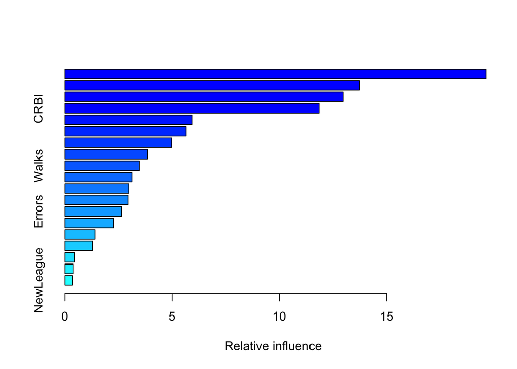

```
##                 var    rel.inf
## CAtBat       CAtBat 19.6278557
## CRuns         CRuns 13.7403200
## CHits         CHits 12.9758404
## CRBI           CRBI 11.8457768
## CHmRun       CHmRun  5.9370171
## CWalks       CWalks  5.6509231
## PutOuts     PutOuts  4.9804392
## Years         Years  3.8633401
## Walks         Walks  3.4795505
## AtBat         AtBat  3.1350637
## RBI             RBI  2.9835714
## Hits           Hits  2.9462067
## Errors       Errors  2.6466136
## HmRun         HmRun  2.2713338
## Assists     Assists  1.4174806
## Runs           Runs  1.3044127
## Division   Division  0.4546588
## League       League  0.3863959
## NewLeague NewLeague  0.3531999
```

```r
summary(best_model_gbm)
```

### 8.10 (g) bagging

The test MSE for bagging is 0.1780639

```r
set.seed(5)

bagged_10g <- randomForest(log_Salary ~ . - Salary, data = train_10b,
                           mtry = (ncol(train_10b)-2),
                           importance = TRUE,
                           ntree = 1000)
pred_bag_10g <- predict(bagged_10g, newdata = test_10b)
mean((pred_bag_10g - test_10b$log_Salary)^2)
```

```
## [1] 0.1780639
```

Compared all the test MSE, bagging performs better than boosting, and tree-based methods perform better than linear methods.

```r
bagging_test <- mean((pred_bag_10g - test_10b$log_Salary)^2)

data.frame(method = c("Boosting", "Linear Regression", "Lasso", "Bagging"),
           test_MSE = c(test_MSE_gbm, test_MSE_lm, test_MSE_lasso, bagging_test)) %>%
  arrange(test_MSE)
```

```
##              method  test_MSE
## 1           Bagging 0.1780639
## 2          Boosting 0.2444733
## 3 Linear Regression 0.3766676
## 4             Lasso 0.4137584
```